# S2.2: con quali profili di espressione diamo i trascritti alle cellule simulate, perché i quadratini somiglino a quelli veri?

geo_spatialtrans, report di step (protocollo v2)

Published

November 6, 2026

# In breve: con quali profili di espressione diamo i trascritti alle cellule simulate, perché i quadratini somiglino a quelli veri?

**A cosa serviva.** Con questo step ogni cellula simulata riceve i suoi trascritti: quanti, e di quali geni. Abbiamo messo in gara tre fonti per i profili di espressione di ogni tipo cellulare. Le prime due vengono dai nuclei veri dei vetrini, con o senza la corona di 8 µm attorno al nucleo. La terza è un atlante a cellula singola con la stessa chimica a sonde di Visium HD, dove esiste. Per giudicarle senza confondere altri effetti, abbiamo tenuto fissi i nuclei veri, i loro quadratini e quanti trascritti cadono in ognuno, e cambiato solo la composizione. Ogni area è stata confrontata con profili stimati sulle altre.

**Cosa abbiamo trovato.**

1. **Vincono i profili dei nuclei veri con la corona, con un po’ di variabilità in più fra cellule dello stesso tipo. Nello stroma del tumore vince l’atlante fatto sugli stessi blocchi del vetrino.**
   - Vale nell’intestino di topo, nel tumore del colon, nel linfonodo e nel cervello di topo.
   - Nel cuore nessuna fonte batte un unico profilo medio del tessuto: con 3-6 trascritti per quadratino le misure non distinguono i tipi, e la scelta è fatta per ordine, come avevamo stabilito.
   - Nel linfonodo e nel cervello l’atlante non è entrato in gara, perché i due link non sono arrivati.
2. **I quadratini simulati somigliano ai veri quanto due aree vere dello stesso tessuto si somigliano fra loro, in 20 confronti su 24.**
   - L’eccezione chiara è l’intestino: nel simulato i blocchi vicini si somigliano un quarto meno che nel vero.
   - La causa è la posizione dei sottotipi, per esempio le cellule di Paneth in fondo alle cripte e gli enterociti lungo i villi. Se ogni cellula tiene il suo sottotipo vero al suo posto, lo scarto scende da un quarto a un sedicesimo. Oggi il simulatore sorteggia il sottotipo senza guardare la posizione.
3. **I sottotipi da soli non riproducono gli zeri in eccesso dell’intestino. Li riproducono se ogni sottotipo ha il suo numero di trascritti per cellula.**
   - Con i sottotipi l’eccesso di zeri simulato è circa un quinto di quello vero.
   - Dando a ogni sottotipo la sua distribuzione dei trascritti, l’eccesso torna entro il margine che avevamo fissato quando abbiamo misurato i trascritti nei quadratini veri. Le altre misure peggiorano al più di un centesimo in tutti i tessuti; nel linfonodo la somiglianza fra blocchi vicini migliora di sei centesimi.
   - La causa sta nel legame fra sottotipo e quantità di trascritti, non nella posizione: lo abbiamo verificato rimescolando i sottotipi fra le cellule in due modi diversi.
4. **Il fattore che porta i trascritti simulati alla profondità vera è sotto 1 in tre tessuti, non sopra come mi aspettavo.**
   - Vale 0.79 nel linfonodo, 0.87 nell’intestino, 0.89 nel tumore; 1.25 nel cervello, 1.58 nello stroma, 2.6 nel cuore.
   - Non manca RNA. Nell’intestino il preset mette il 29 % di cellule in più dei nuclei che Cellpose trova. Nel linfonodo il numero di trascritti per tipo viene dai soli nuclei a cui abbiamo dato un tipo, che ne hanno di più degli altri.
   - Quando rivedremo la densità dei preset, il fattore va ricalcolato.
5. **I revisori hanno trovato due cose vere, e le ho corrette o misurate.**
   - Avevo applicato la regola dei pareggi in modo più largo di come era scritta. Applicata come scritta, nel tumore del colon vincono i nuclei veri invece dell’atlante.
   - Le 5 aree di riferimento di uno stesso tessuto si sovrappongono, fino a quasi due quinti fra due aree, in tutti i tessuti tranne il cuore. Togliendo i nuclei in comune la gara non cambia. Ma l’incertezza calcolata fra aree, qui e in tutti i riferimenti dal conteggio dei nuclei in poi, è più ottimistica del dovuto.

**Cosa devi decidere.**

1. **Diamo a ogni sottotipo la sua distribuzione di trascritti per cellula, invece di una per tipo? Consiglio di sì.**
   - È l’unico modo che abbiamo trovato per riprodurre gli zeri dell’intestino. Negli altri tessuti nessuna misura peggiora di più di un centesimo, e la funzione lo sa già fare.
   - Vale dove i profili vengono dai nuclei veri. Nello stroma i sottotipi vengono dall’atlante, dove non abbiamo i trascritti misurati con Visium HD, e resterebbe un valore per tipo.
   - Alternativa: tenere un valore per tipo, come deciso quando abbiamo misurato i trascritti nei quadratini veri. Conseguenza: l’intestino simulato avrà meno zeri del vero, e i metodi che lavorano sugli zeri lo troveranno più facile.
2. **Chiudiamo lo step anche se due controlli automatici non sono passati come li avevo scritti? Consiglio di sì.**
   - Il primo controlla che i profili si ricostruiscano dalle cellule simulate. Ho fissato la soglia per un gene alla volta, ma i confronti erano fino a 140 000. Con tanti confronti qualche scarto oltre soglia è atteso per caso, e la distribuzione degli scarti è esattamente quella del caso.
   - Il secondo è il ricalcolo indipendente: differisce solo per i quadratini a pari distanza da due nuclei, che due programmi assegnano in modo diverso. L’effetto è al più di un millesimo.
   - Alternativa: riscrivere le due soglie e rifare i controlli in uno step dedicato. Nessun numero cambierebbe.
3. **Misuriamo, in uno step dedicato, quanto la sovrapposizione delle aree cambia l’incertezza dei riferimenti passati? Consiglio di sì, prima di confrontare il simulatore completo con i tessuti veri.**
   - Tocca tutti i riferimenti misurati per area: densità, aree dei nuclei, trascritti per quadratino e per cellula, strisce.
   - Alternativa: ridisegnare aree che non si sovrappongono e rifare quei riferimenti. È più pulito, ma costa molti step.
   - Alternativa: non fare nulla e dichiararlo. Gli intervalli dei riferimenti resterebbero ottimistici.

**Comunque**: quando arriveranno i link degli atlanti del linfonodo e del cervello rifaremo la gara in quei due tessuti, in pochi minuti. La disposizione dei sottotipi nello spazio va messa in conto quando il simulatore piazzerà i sottotipi e non solo i tipi. Il fattore di profondità si ricalcola con la revisione della densità dei preset e si verifica quando metteremo insieme tutto lo Step 2. Nel cuore i profili per tipo non si possono giudicare con questi dati.

Appena decidi questi 3 punti, lo step è chiuso.

# Decisioni e verifiche di Luca

- «Atlante Flex dove esiste (Recommended)» (chat, 2026-11-05): perimetro della gara.
- «Ok, come proposte (Recommended)» (chat, 2026-11-05): previsioni P-1…P-6, soglia del fattore di profondità (1-2), regola dei pareggi della gara.
- «VPN riaccesa, continua (Recommended)» (chat, 2026-11-06).
- «ok chiudi» (chat, 2026-11-06): risposta alle tre decisioni del riassunto, lette come le tre raccomandazioni: un totale per sottotipo dove i profili vengono dai nuclei veri (DEC-046); chiusura con G-2 e G-5 falliti come scritti (DEC-047); step sulle aree sovrapposte prima di S2.5 (DEC-048).

# Dubbi rinviati

| cosa | perché | cosa serve per chiuderlo | step destinatario | voce di BACKLOG |
| --- | --- | --- | --- | --- |
| atlante a sonde per linfonodo e cervello (link non arrivati) e per intestino e cuore (non trovato) | il sito di 10x blocca i download automatici | i link da Luca; rifare la gara nei due tessuti con `tools/S2.2_race.py` | da assegnare | BL-217 |
| sottotipi disposti nello spazio (intestino: blocchi vicini −0.24 contro −0.06 con la posizione vera) | lo Step 1 piazza tipi, non sottotipi | semina dei sottotipi per compartimento o campo spaziale | da assegnare | BL-216 |
| aree di riferimento sovrapposte (fino al 39 %): incertezza fra aree ottimistica da R2 in poi | proprietà del disegno delle aree di R2 | step dedicato (step sulle aree sovrapposte prima di S2.5 (DEC-048)) | R7 (id proposto), prima di S2.5 | BL-215 |
| fattore di profondità da ricalcolare con le densità nuove; verifica su una sezione | dipende dalla densità dei preset e dallo spostamento | `tools/S2.2_depth.py` dopo la revisione delle densità; verifica in S2.5 | con BL-167 e BL-213; S2.5 | BL-218, BL-205 |
| 111 geni di Visium HD senza profilo nello stroma (atlante) | universo dei geni dell’atlante | controllo in S2.5 della quota di UMI veri su quei geni | S2.5 | BL-219 |

# Cancelli, previsioni e controprova

Tabelle: `results/S2.2/S2.2_race_scores.csv`, `S2.2_race_winners.csv`, `S2.2_predictions.csv`, `S2.2_CP1.csv`, `S2.2_P5_CP2.csv`, `S2.2_depth_factor.csv`.

**Regole decise dai dati (R-1, R-2, R-3)**, registrate in S2.2: fonte dei profili, modello di conteggio e fattore di profondità decisi dai dati (DEC-045).

| tessuto | vincitore (fonte, modello) | punteggio | secondo | come |
| --- | --- | --- | --- | --- |
| intestino (A1) | R6 impronta intera, G | 0.074 | R6 solo nucleo, G (0.097) | punteggio |
| tumore (A2) | R6 impronta intera, G | 0.036 | R6 impronta intera, M (0.047) | punteggio |
| stroma (A3) | atlante, M | 0.042 | R6 impronta intera, G (0.043) | pareggio, ordine |
| linfonodo (A4) | R6 impronta intera, G | 0.060 | R6 solo nucleo, G (0.081) | punteggio (senza atlante, deviazione 1) |
| cervello (A5) | R6 impronta intera, G | 0.015 | R6 impronta intera, M (0.027) | punteggio (senza atlante, deviazione 1) |
| cuore (A6) | R6 impronta intera, M | 0.085 | (primo: R6 impronta intera, G, 0.083) | pareggio, ordine; banco senza potere (CP-1) |

Fattore di profondità (R-3): intestino 0.87 [0.82, 0.91]; tumore 0.89 [0.76, 1.05]; stroma 1.58 [1.31, 1.78]; linfonodo 0.79 [0.72, 0.84]; cervello 1.25 [1.18, 1.33]; cuore 2.62 [1.94, 3.31] (intervallo bootstrap sulle 5 aree, ottimistico per la deviazione 5).

**Cancelli.**

[output not shown]

**Previsioni** (vincitore di R-1; scarto relativo medio ± 2 errori standard fra le 5 aree; intervallo = differenza massima fra due aree vere).

| tessuto | m1 geni per quadratino | m2 geni per blocco di 8 µm | m3 somiglianza fra blocchi vicini | m4 misura di Daniele |
| --- | --- | --- | --- | --- |
| intestino | +0.003 [−0.000, +0.007] / ±0.010 confermata | +0.023 [+0.018, +0.029] / ±0.028 indeterminata | −0.241 [−0.273, −0.208] / ±0.099 **smentita** | +0.022 [−0.004, +0.048] / ±0.064 confermata |
| tumore | +0.007 [+0.000, +0.014] / ±0.012 indeterminata | +0.017 [+0.006, +0.028] / ±0.032 confermata | −0.030 [−0.102, +0.042] / ±0.184 confermata | +0.029 [−0.018, +0.077] / ±0.191 confermata |
| stroma | −0.000 [−0.011, +0.011] / ±0.042 confermata | +0.011 [−0.004, +0.027] / ±0.053 confermata | +0.026 [−0.069, +0.122] / ±0.252 confermata | −0.029 [−0.084, +0.027] / ±0.130 confermata |
| linfonodo | +0.013 [+0.005, +0.022] / ±0.035 confermata | +0.037 [+0.021, +0.052] / ±0.057 confermata | −0.151 [−0.231, −0.070] / ±0.252 confermata | −0.041 [−0.078, −0.004] / ±0.096 confermata |
| cervello | +0.001 [+0.000, +0.002] / ±0.005 confermata | +0.006 [+0.003, +0.009] / ±0.037 confermata | +0.016 [−0.013, +0.045] / ±0.114 confermata | +0.007 [−0.022, +0.036] / ±0.110 confermata |
| cuore | +0.001 [−0.006, +0.008] / ±0.020 confermata | −0.005 [−0.035, +0.026] / ±0.099 confermata | +0.143 [−0.129, +0.414] / ±0.691 confermata | −0.055 [−0.078, −0.033] / ±0.075 indeterminata |

P-1…P-4: 20 confermate, 3 indeterminate, 1 smentita su 24. La direzione attesa di P-2 (simulato sopra il vero) si vede in 5 tessuti su 6; quella di P-3 (simulato sotto il vero) nell’intestino e nel linfonodo; quella di P-4 (sotto nel linfonodo e nell’intestino) solo nel linfonodo.

- **P-5 smentita**: zeri in eccesso dell’intestino, simulato 0.009 [0.006, 0.018] contro vero 0.043 (lo stesso valore di R4, 205 coppie); differenza −0.034 [−0.038, −0.020], fuori da ±0.02. Spiegata da PH-1b/c e PH-3.
- **P-6**: confermata nello stroma (1.58) e nel cervello (1.25); **smentita** nell’intestino (0.87) e nel linfonodo (0.79), sotto 1; indeterminata nel tumore (0.89 [0.76, 1.05]). Nel cuore 2.62, come atteso (circa 3; per il cuore non c’era un intervallo). Spiegata da PH-2: la causa non è RNA mancante ma la densità dei preset e il totale medio dei soli nuclei con un tipo.

**Controprova.** CP-1: i due profili sbagliati perdono di più di 2 errori standard in 5 tessuti su 6; nel cuore pareggiano (un profilo medio del tessuto senza tipi fa come i profili per tipo: con 3-6 UMI per quadratino le misure non distinguono i tipi). Il vincitore del cuore è quindi una scelta per ordine, come scritto. CP-2 confermata come scritta (senza sottotipi 0.004, sotto 0.02), ma poco informativa: anche con i sottotipi l’indice resta basso (P-5).

## La gara per tessuto

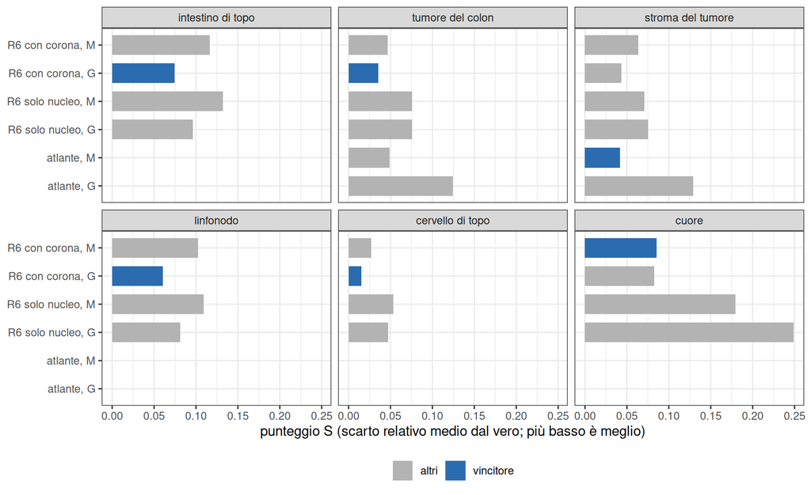

Figure 1

Cosa guardare: il vincitore per tessuto e la distanza dal secondo. Nel linfonodo e nel cervello manca l’atlante (deviazione 1). Nel cuore il profilo medio senza tipi fa come i profili per tipo (CP-1 in `S2.2_CP1.csv`).

## Da dove vengono gli scarti dell’intestino (analisi post hoc)

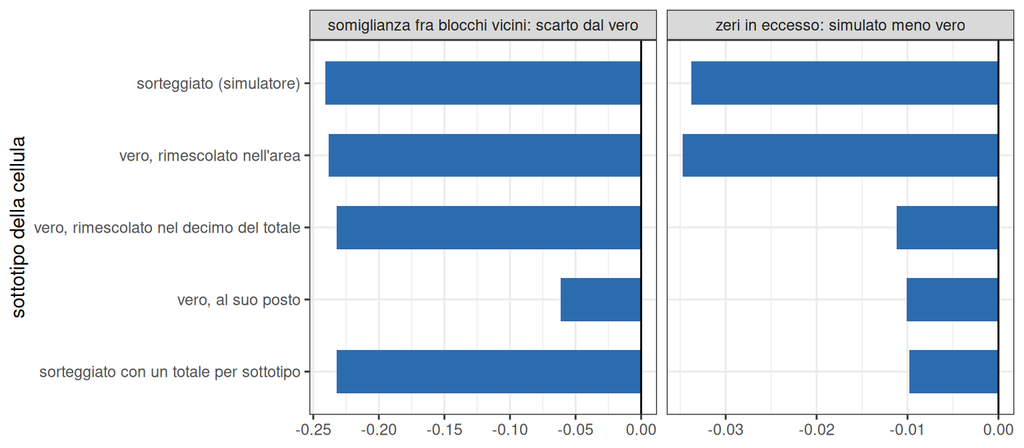

Figure 2

Cosa guardare: la somiglianza fra vicini torna solo con il sottotipo vero al suo posto (posizione); gli zeri tornano anche rimescolando dentro il decimo del totale e con un totale per sottotipo (legame sottotipo-totale).

- **PH-1, sottotipi «oracolo»** (ogni cellula vera riceve il suo gruppo di R6; disposizione nello spazio vera), tutti i tessuti, `results/S2.2/S2.2_PH1.csv`. Nell’intestino la somiglianza fra blocchi vicini passa da −0.24 a −0.06 (modello G) e l’indice degli zeri da 0.009 a 0.032 (vero 0.043). Negli altri tessuti cambia poco, salvo il linfonodo (m3 da −0.15 a −0.01).
- **PH-1b/c** (solo intestino): i gruppi veri rimescolati fra le cellule dello stesso tipo nell’area (b) o dentro i decimi del totale della cellula (c). La somiglianza fra vicini torna a −0.24 in entrambi: viene dalla **posizione** dei sottotipi. L’indice degli zeri torna a 0.008 con (b) e resta a 0.031 con (c): viene dal **legame fra sottotipo e totale della cellula**, non dalla posizione (`S2.2_PH1_P5.csv`).
- **PH-3, un totale per sottotipo** (sottotipo estratto dentro il decimo del totale; equivale a dare a ogni sottotipo la sua distribuzione dei totali), tutti i tessuti: indice degli zeri 0.033, differenza dal vero −0.010 [−0.018, +0.005], dentro ±0.02; le altre misure peggiorano al più di 0.011 (stroma m3, con la fonte R6 che nello stroma non vince) e migliorano altrove (linfonodo m3 da −0.15 a −0.09). Implementato in `simulate_cell_profiles(totals_by = "subtype")` con i quantili per sottotipo delle fonti R6 (test i1-i5, mutante M9); dopo la decisione di Luca è il predefinito nei tessuti con i profili di R6 (S2.2: un totale per sottotipo dove i profili vengono dai nuclei veri (DEC-046)); G-1…G-4 rifatti con questo predefinito.
- **PH-2, scomposizione del fattore di profondità** (`S2.2_PH2.csv`), esatta: f = (UMI dell’area / UMI nelle impronte dei nuclei) × (nuclei veri / cellule simulate) × (totale medio vero per nucleo / totale medio simulato) × fondo. Intestino: impronte 0.89, nuclei/cellule 0.77 (il preset mette il 29 % di cellule in più dei nuclei trovati da Cellpose), totali 1.00. Tumore: 0.94, 0.83, 1.01. Linfonodo: 1.00, 0.99, 0.81 (i totali per tipo vengono dai nuclei con un tipo; quasi metà dei nuclei del linfonodo non ha tipo e ha meno trascritti). Stroma: 0.85, 1.37 (il preset mette meno cellule dei nuclei), 0.99. Cervello: 0.57 (molto RNA fuori dalle impronte, nel neuropilo), 0.74, 1.02. Cuore: 0.37, 1.00, 1.04.
- **PH-4, distribuzione degli z di G-2** (`S2.2_PH4.csv`): vedi G-2.
- **PH-5, gara senza i nuclei dell’area tenuta fuori** (`results/S2.2/PH5/`): vedi deviazione 5.

# Revisione avversariale

Due revisori indipendenti con codice proprio (cartelle `/mnt/micron/geo_spatialtrans/S2.2/review/`).

- **Revisore dei numeri**: misure vere del banco in 6 aree (una per tessuto) dalla matrice di Space Ranger: identiche nel cuore; altrove scarti da pareggi di distanza (G-5 a, spiegato); sullo stesso insieme di quadratini identiche entro 2e-16. Punteggi e vincitori di intestino e tumore identici fino a 1e-16; ha trovato che la regola dei pareggi applicata non era quella scritta (deviazione 2, corretta: vincitore del tumore cambiato). Una replica del braccio R6 impronta intera, M nell’intestino con codice proprio: m1, m2, m3 entro 1 z dalle 3 repliche. Totali per tipo (23) e fattore di profondità (30 aree, 6 tessuti) identici.
- **Revisore del codice**: distribuzione dei trascritti fra i quadratini, profili, φ, allineamento dei geni con l’atlante, semi, riproducibilità in R corretti (ricalcolati). Rilievi: aree sovrapposte (deviazione 5, PH-5); atlante mancante passato in silenzio (deviazione 1); regola dei pareggi (deviazione 2); sottotipi resto (3); fuga dei gruppi di Leiden (4); mutanti (6) e G-1 (f) (7); 111 geni dell’atlante (8); controlli d’ingresso mancanti nella funzione (aggiunti: cell_id duplicati o NA, quote che non sommano a 1, NA nei quantili, sottotipi senza conteggi; test d11-d13); profilo per tipo con `use_subtypes = FALSE` pesato solo con le quote (documentazione corretta); in G-3 il numero di processi della gara cambia solo quanti tessuti girano insieme (la gara è un processo per tessuto: il controllo vale per il pannello in R).

# Deviazioni dichiarate

1. **Atlante del linfonodo e del cervello non usato.** Il sito di 10x risponde 429 ai download automatici; i link chiesti a Luca il 2026-11-05 non sono arrivati prima del calcolo. Nel linfonodo e nel cervello la gara è a due candidate (come previsto dal perimetro in questo caso). Lo script della gara passava in silenzio a «senza atlante» quando il file mancava (revisione del codice): la deviazione è scritta qui e nella voce di BACKLOG sull’atlante. Con i link, la gara in quei due tessuti si rifà in pochi minuti.
2. **Regola dei pareggi applicata come scritta dopo la revisione.** Il primo punteggio metteva in pareggio con il primo ogni braccio entro 2 errori standard; R-1 dice «fra il secondo e il primo». Nel tumore del colon il terzo (atlante, multinomiale) pareggiava per rumore e vinceva per ordine. Applicata la regola come scritta (`tools/S2.2_score.py`), nel tumore vince R6 impronta intera con il modello G; negli altri cinque tessuti nulla cambia.
3. **Sottotipi «resto».** I sottotipi con meno di 30 cellule di stima si fondono in un gruppo «tipo|rest», che può restare sotto 30 cellule (stroma, endoteliali: 27; cervello, vascolari: 18). È la lettura scelta di «si fonde nel resto del suo tipo».
4. **Gruppi di R6 calcolati su tutte e 5 le aree.** I sottotipi di R6 (gruppi di Leiden) sono stati definiti in R6 con tutte le aree, compresa quella tenuta fuori; i profili e le quote sono stimati solo sulle 4 aree di stima. Fuga lieve nella definizione dei gruppi, non nei conteggi.
5. **Aree che si sovrappongono.** Le 5 aree di R2 dello stesso tessuto si sovrappongono fisicamente (fino al 39 % fra due aree; nessuna nel cuore), cosa non nota prima di questo step (revisione del codice). Nella gara i profili «delle altre 4 aree» contenevano anche nuclei dell’area tenuta fuori. Rifatta la gara togliendoli (PH-5): punteggi cambiati al più di 0.0033, stessi vincitori e stessi esiti. Nei profili finali ogni nucleo conta una volta. Gli errori standard fra aree (qui e nei passi precedenti) sono ottimistici di una quantità non stimata: voce di BACKLOG.
6. **Mutanti.** Il mutante «rinormalizzazione tolta» non è stato usato: in R `rmultinom()` normalizza da sé, quindi è equivalente (uscita identica bit per bit, revisione del codice). «Sottotipo sfasato» è realizzato come quote invertite. Il criterio «almeno 6 mutanti, tutti rilevati» resta soddisfatto (9 su 9).
7. **G-1 (f)**: il test usa un margine del 5 % sulla varianza (circa 3 errori standard con 20 000 cellule), più severo del |z| < 5 scritto.
8. **Atlante nello stroma: 111 geni senza profilo.** I geni di Visium HD assenti dall’atlante hanno profilo 0 nello stroma simulato; i totali per cellula restano quelli di R6 su tutti i geni, quindi l’1 % circa degli UMI veri, che cade su quei geni, va sugli altri. Limite dichiarato, voce di BACKLOG.

# Cosa è girato

- Commit della pre-registrazione: `c7ef7b1`, `edbd012` (cancelli), `9eb1c1b` (ok di Luca), `6035eb2` e `abf8d70` (correzioni prima del calcolo); chiusura in questo commit.
- Banco: `tools/S2.2_real.py` (5 processi su 5 dataset), gara `tools/S2.2_race.py` (un processo per tessuto, 4 in parallelo; 14 bracci, 3 repliche, semi 20261106 + 1000 r + braccio, per area), punteggi `tools/S2.2_score.py`, fattore `tools/S2.2_depth_layers.R` + `tools/S2.2_depth.py`, profili `tools/S2.2_build_profiles.py`, pannello `tools/S2.2_panel.R` (semi 20261108, 20261109), post hoc `tools/S2.2_posthoc_*.py|R`, riproduzione `tools/S2.2_repro.sh`, `tools/S2.2_repro_content.R`, mutanti `tools/S2.2_mutants.sh`.
- Esecuzione finale di G-1…G-4 dopo DEC-046 (totale per sottotipo come predefinito).
- Durata: banco circa 10 minuti; gara circa 10 minuti per tessuto; pannello circa 5 minuti con 4 processi (la funzione: 0.6-6 s per area di 1 mm² con 4 processi). Server condiviso: tempi non da manoscritto.
- md5: `results/S2.2/S2.2_md5_before.txt`, `S2.2_md5_after.txt` (188 file identici); atlante `S2.2_atlas_md5.txt`; profili `S2.2_profiles_md5.txt`.

Fattore di profondità per tessuto (regola R-3)

| archetype | f | lo | hi | f_min | f_max |
| --- | --- | --- | --- | --- | --- |
| A1 | 0.867 | 0.824 | 0.908 | 0.805 | 0.920 |
| A2 | 0.893 | 0.757 | 1.052 | 0.670 | 1.150 |
| A3 | 1.584 | 1.315 | 1.778 | 1.059 | 1.828 |
| A4 | 0.787 | 0.717 | 0.839 | 0.656 | 0.864 |
| A5 | 1.252 | 1.177 | 1.326 | 1.144 | 1.343 |
| A6 | 2.625 | 1.938 | 3.312 | 1.738 | 3.661 |

# Appendice

## Perimetro

Scelto da Luca il 2026-11-05 («Atlante Flex dove esiste (Recommended)»): la gara sulla fonte dei profili ha tre candidate dove esiste un atlante a cellula singola con la stessa chimica a sonde di Visium HD (Chromium Flex), due altrove.

| tessuto | candidate |
| --- | --- |
| intestino di topo (A1) | R6 impronta intera (nucleo + corona fino a 8 µm); R6 solo nucleo |
| tumore del colon (A2), stroma del tumore (A3) | le due di R6; atlante Flex di Oliveira 2025, paziente P2 (lo stesso blocco del vetrino), cellule `QCFilter == Keep`[^oliveira] |
| linfonodo (A4) | le due di R6; dataset dimostrativo 10x «320k scFFPE» (GEM-X Flex), campione di linfonodo |
| cervello di topo (A5) | le due di R6; dataset dimostrativo 10x «10k Mouse Forebrain FFPE» (Flex) |
| cuore (A6) | le due di R6 |

Per l’intestino e il cuore l’atlante a sonde non c’è: la voce va in BACKLOG. I due dataset dimostrativi 10x non hanno DOI: entrano come dataset più script (principio 6), con md5 in `results/S2.2/S2.2_atlas_md5.txt`. Se i loro link non arrivano, linfonodo e cervello restano a due candidate e lo si scrive come deviazione.

Lo step consegna: (1) gli esiti della gara e delle altre due scelte decise dai dati; (2) `simulate_cell_profiles()` in `R/05b2_simulate_cell_profiles.R`, con la batteria `R/testing/test_S2.2.R`; (3) l’insieme dei profili vincitori per i sei tessuti, con builder e md5.

## Dubbi ricevuti

| voce | cosa | come la tratta S2.2 |
| --- | --- | --- |
| BL-194 | nell’intestino gli zeri in eccesso vengono da marcatori di sottotipi dentro i tipi grossolani; servono sottotipi o programmi, non un dropout | i profili hanno sottotipi (gruppi dentro il tipo); previsione P-5 e controprova CP-2 sullo stesso indice di R4 (PH-2) |
| BL-204 | misura di Daniele: somiglianza fra i quadratini della stessa cellula contro cellule diverse dello stesso tipo | misura m4 del banco, sui veri (E-1) e sui simulati; criterio della gara e previsione P-4 |
| BL-205 | bilancio dei trascritti per area e fattore di profondità per tessuto | regola R-3 (fattore per tessuto appaiato per area) e previsione P-6; verifica su una sezione in S2.5 |
| BL-203 | confronto del modello di rumore con scDesign3 | non trattato qui (resta di S2.x); la scelta fra multinomiale e binomiale negativa per gene è la regola R-2 |

## Attese pre-registrate

Commit dei cancelli: `c7ef7b1` (link corretto in `edbd012`). Ok di Luca sulle previsioni, sulla soglia del fattore di profondità e sulla regola dei pareggi: 2026-11-05, «Ok, come proposte (Recommended)». Commit: vedi `git log` («S2.2: ok di Luca sulle previsioni»).

Unità indipendente per l’incertezza: l’area (ROI), 5 per tessuto. Nella gara ogni area vera è tenuta fuori a turno dalla stima dei profili di R6 (validazione lasciando fuori un’area); l’errore di una candidata si calcola per area e l’errore standard fra le 5 aree. Repliche Monte Carlo: 3 per braccio e per area, semi `20261106 + 1000 · r + indice del braccio` (r = 0, 1, 2); seme della divisione in metà delle cellule (misura m4) = 20261106, lo stesso per veri e simulati. Bootstrap del fattore di profondità: sulle 5 aree, B = 2000, seme 20261107. Processi: al più 6 (server condiviso).

### Il banco della gara (geometria vera, composizione simulata)

Per ogni area vera: i quadratini di 2 µm in tessuto che cadono nell’impronta di un nucleo vero (nucleo più corona fino a 8 µm, la stessa regola di R6) con un tipo del preset del tessuto (criterio corretto di R6; nell’intestino, nel tumore e nello stroma «epiteliale normale» e «tumorale» sono l’unico tipo «epiteliale» del preset, DEC-014). Sono i «quadratini di valutazione»; ogni cellula di valutazione ha il suo totale vero N_c (somma sui suoi quadratini) e ogni quadratino il suo totale vero.

Per ogni candidata e ogni cellula di valutazione dell’area tenuta fuori:

1. il sottotipo si estrae dalle quote dei sottotipi del suo tipo nella candidata (non dal gruppo della cellula vera: il simulatore conosce solo il tipo);
2. i conteggi per gene: multinomiale (N_c, profilo del sottotipo) nel modello M; nel modello G il profilo è prima moltiplicato gene per gene da un fattore gamma di media 1 e varianza φ_g e rinormalizzato (binomiale negativa per gene, con totale fissato);
3. i trascritti della cellula si distribuiscono a caso fra i suoi quadratini con i totali veri dei quadratini (ipergeometrica multivariata).

Così i quadratini simulati hanno la stessa geometria e gli stessi totali dei veri, e differiscono solo per la composizione: la gara giudica la fonte dei profili e il modello di conteggio, non lo spostamento dei trascritti (S2.3) né la cattura (S2.4). Limite dichiarato: nei quadratini veri ci sono anche trascritti dei vicini spostati, che il banco non aggiunge.

**Universo dei geni**: nei tessuti con l’atlante, i geni (identificativo Ensembl) presenti sia nella matrice di Visium HD sia nell’atlante; altrove tutti i geni della matrice. Misure vere e simulate sullo stesso universo.

**Candidate.**

- R6 impronta intera: conteggi per nucleo di `R6/counts/<A>_<roi>_exp.npz` delle 4 aree di stima;
- R6 solo nucleo: `R6/counts/<A>_<roi>_nuc.npz` delle stesse 4 aree, stessi nuclei;
- atlante: cellule dell’atlante con il tipo del catalogo del preset. Dove gli autori danno un’annotazione (tumore del colon) la si mappa al catalogo con questa tabella: Tumor e Intestinal Epithelial → epiteliale; Fibroblast → fibroblasti; Endothelial → endoteliale; T cells, B cells, Myeloid → immunitario; Smooth Muscle e Neuronal fuori dal catalogo dei preset. Senza annotazione (linfonodo, cervello) i tipi si danno con la pipeline di R6: normalizzazione, 2 000 geni variabili, 30 componenti, 15 vicini, Leiden a risoluzione 1, seme 20261022, nome del gruppo con il criterio corretto (arricchimento dei 50 geni più caratteristici nei marcatori PanglaoDB del catalogo, `tools/R6_relabel.py`).

**Profilo** di un tipo o sottotipo: somma dei conteggi delle sue cellule diviso il totale (stima di massima verosimiglianza della multinomiale). **Sottotipi**: per R6 i gruppi di Leiden di R6 dentro il tipo; per l’atlante annotato i suoi `Level2` dentro il tipo; per l’atlante non annotato i gruppi di Leiden della pipeline sopra. Un sottotipo con meno di 30 cellule di stima si fonde nel resto del suo tipo. **Quote dei sottotipi**: frazione di cellule. **φ_g** (modello G): stima dei momenti sulle cellule di stima, dentro i sottotipi, con il fattore di taglia di ogni cellula: φ_g = max(0, Σ_c [(x_cg − μ_cg)² − μ_cg] / Σ_c μ_cg²), μ_cg = N_c · p_sub(c),g.

**Misure** (stesse funzioni per veri e simulati, `tools/S22_common.py`): m1 geni rilevati per quadratino di 2 µm; m2 geni rilevati per blocco di 8 µm (blocchi con almeno 12 dei 16 quadratini di valutazione, somma sui soli quadratini di valutazione); m3 coseno medio fra i conteggi di blocchi di 8 µm adiacenti; m4 misura di Daniele: coseno fra le due metà (a caso) dei quadratini della stessa cellula, diviso il coseno fra metà di cellule diverse dello stesso tipo a più di 30 µm. La sparsità a 2 e 8 µm è 1 − m1/G e 1 − m2/G sullo stesso universo: si riporta, ma non aggiunge informazione.

### Regole di decisione dei dati (scritte prima del calcolo)

**R-1, fonte dei profili** (DEC-040 punto 1). Per ogni tessuto, braccio a (fonte × modello di conteggio) e area k: e_mk = (simulato − vero) / vero per m ∈ {m1, m2, m3, m4}, con il simulato medio delle 3 repliche. Punteggio dell’area S_ak = media su m di |e_mk|; punteggio del braccio S_a = media su k. Vince il braccio con S_a minore. Pareggio: se la differenza appaiata per area fra il secondo e il primo ha media minore di 2 errori standard (deviazione standard fra le 5 aree / √5), si sceglie per ordine: fonte atlante, poi R6 solo nucleo, poi R6 impronta intera (meno trascritti dei vicini, che S2.3 aggiungerà da sé); modello M prima di G (un parametro in meno). Si sceglie per tessuto. m4 non era fra le misure di DEC-040: la si aggiunge perché in E-1 m1 risulta quasi fissata dalla profondità (geni per UMI 0.93-0.98 in tutti i tessuti), e la misura di Daniele è quella che guarda i profili dentro la cellula (decisione tecnica, registrata con lo step).

**R-2, modello di conteggio**: deciso dentro R-1 (bracci M e G).

**R-3, fattore di profondità** (DEC-040 punto 2). Per ogni area k del pannello dello Step 1 (livelli di S1.6 con il predefinito dei preset, `S1.6/layers/<A>_<roi>_U6.rds`): f_k = (UMI veri medi per bin di 2 µm in tessuto dell’area k, `R4_roi.csv` `mean_umi2`, − fondo b del tessuto, B-342…B-366) / (Σ sulle cellule simulate del totale medio del loro tipo / numero di bin di 2 µm in tessuto dell’area simulata, cioè area dei territori / 4 µm²). Fattore del tessuto = media delle 5 aree, intervallo bootstrap sulle aree. I totali per tipo sono la distribuzione empirica dei totali dei nuclei veri classificabili (impronta intera, almeno 20 UMI) di R6, sulle 5 aree. Le perdite verso il vetro per lo spostamento non entrano qui: si verificano in S2.5.

### Cancelli (al massimo 5)

[output not shown]

### Previsioni

Intervalli di rilevanza (fonte di tipo 2, variabilità misurata sui dati veri, E-1): la differenza massima fra due aree vere dello stesso tessuto, relativa alla media, `results/S2.2/S2.2_E1_relevance.csv`. Uno scarto del simulato dal vero più piccolo della differenza fra due aree vere dello stesso tessuto non si distingue dalla variabilità del tessuto; uno più grande sì. m1 e m2 si confrontano come geni per UMI (la profondità varia fra le aree e nel banco è la stessa per vero e simulato). Il giudizio usa lo scarto relativo con segno medio sulle 5 aree tenute fuori ± 2 errori standard fra le aree, per il braccio vincitore della regola R-1.

| tessuto | m1 | m2 | m3 | m4 |
| --- | --- | --- | --- | --- |
| intestino (A1) | ±0.010 | ±0.028 | ±0.099 | ±0.064 |
| tumore (A2) | ±0.012 | ±0.032 | ±0.184 | ±0.191 |
| stroma (A3) | ±0.042 | ±0.053 | ±0.252 | ±0.130 |
| linfonodo (A4) | ±0.035 | ±0.057 | ±0.252 | ±0.096 |
| cervello (A5) | ±0.005 | ±0.037 | ±0.114 | ±0.110 |
| cuore (A6) | ±0.020 | ±0.099 | ±0.691 | ±0.075 |

Nel cuore l’intervallo di m3 è largo (la profondità cambia di due volte fra le aree e il coseno ne dipende): lì m3 dice poco, e lo si sa prima.

| id | quantità | tessuti | atteso | intervallo di rilevanza | fonte dell’intervallo | 2 errori standard tipici |
| --- | --- | --- | --- | --- | --- | --- |
| P-1 | m1, geni per quadratino di 2 µm, scarto relativo del vincitore | A1-A6 | confermata in 6 su 6: a 2 µm quasi ogni UMI è un gene diverso | tabella sopra | E-1 | da stimare; l’errore è appaiato per area, quindi atteso sotto l’intervallo |
| P-2 | m2, geni per blocco di 8 µm | A1-A6 | simulato sopra il vero di 2-10 %: le cellule vere concentrano i trascritti nei loro programmi più del profilo medio del sottotipo | tabella sopra | E-1 | idem |
| P-3 | m3, somiglianza fra blocchi di 8 µm adiacenti | A1-A6 | simulato sotto il vero, soprattutto nell’intestino e nel cervello: il banco perde la disposizione spaziale dei sottotipi e i trascritti dei vicini | tabella sopra | E-1 | idem |
| P-4 | m4, misura di Daniele | A1-A6 | simulato sotto il vero nell’intestino (vero 2.1) e nel linfonodo (vero 1.8): differenze fra cellule dello stesso tipo più continue dei sottotipi; vicino al vero altrove (vero 1.1-1.3) | tabella sopra | E-1 | idem |
| P-5 | zeri in eccesso dell’intestino, indice di R4 (binomiale negativa con fattore di taglia, geni con media ≥ 2), cellule simulate del vincitore contro cellule vere | A1 | simulato entro ±0.02 dal vero (+0.043 in R4): i sottotipi bastano a spiegare gli zeri | ±0.02 | la soglia pre-registrata e approvata in R4 per lo stesso indice | bootstrap sulle aree, circa 0.02 in R4 |
| P-6 | fattore di profondità f per tessuto | A1-A6 | 1.2-1.5 in A1-A5 (la revisione di S2.0 stimava il 67-82 % degli UMI veri senza fattore), circa 3 nel cuore | f fra 1 e 2 in A1-A5: oltre 2, più di metà dell’RNA del tessuto non verrebbe dalle cellule come le misuriamo, e il limite dello spazio acellulare (D2-11) diventerebbe un problema | scelta da approvare (fonte di tipo 3) | bootstrap sulle 5 aree |

Attesa non giudicata sulla gara: R6 impronta intera vince nella maggior parte dei tessuti (porta con sé i trascritti dei vicini, che i quadratini veri contengono).

### Controprova

**CP-1, il banco distingue i profili?** Due candidate sbagliate di proposito, nel modello M: (a) un solo profilo medio del tessuto, senza tipi né sottotipi; (b) il profilo medio di un altro tessuto della stessa specie (intestino ↔︎ cervello; tumore e stroma ↔︎ cuore; linfonodo ↔︎ tumore; cuore ↔︎ linfonodo). Se il banco ha potere, entrambe perdono contro il vincitore di più di 2 errori standard del punteggio appaiato, in ogni tessuto. Se in un tessuto una delle due pareggia, la gara in quel tessuto non ha potere e il suo vincitore si legge come scelta per ordine.

**CP-2, i sottotipi spiegano gli zeri dell’intestino?** Il vincitore di A1 con i sottotipi spenti (un solo profilo per tipo): l’indice di P-5 deve scendere sotto +0.02. Se restasse alto anche senza sottotipi, gli zeri non verrebbero dai sottotipi e BL-194 resterebbe aperta.

## Correzioni prima del calcolo (dichiarate, commit separato)

1. **R-3, media e non mediana.** Il testo approvato diceva «mediana del totale del loro tipo». Il simulatore estrae i totali dalla distribuzione empirica del tipo, quindi il totale atteso di una cellula è la media, non la mediana: con la mediana il fattore verrebbe sovrastimato quanto la distribuzione è asimmetrica. Corretto prima di calcolare il fattore; le soglie di P-6 restano come approvate.
2. **Semi della gara, precisazione.** Il seme dichiarato (20261106 + 1000 · r + indice del braccio) si combina con l’indice dell’area (`numpy.random.default_rng([seme, area])`), così due aree non condividono la stessa sequenza casuale. Nessun calcolo della gara era stato giudicato prima di questa riga; una prova di funzionamento sul cuore (un’area, nessun punteggio) è servita a controllare il codice.
3. **G-2, profili ricostruiti solo con il modello M.** Il controllo «profili ricostruiti come in G-1 (b)» usa la varianza multinomiale e il profilo dato come atteso. Con il modello G (vincitore in intestino, linfonodo e cervello) il profilo atteso di una cellula non è esattamente quello dato: dopo il fattore gamma si rinormalizza, e per i geni molto espressi e molto dispersi la media scende (al primo ordine di p_g · φ_g). Anche la varianza è più grande. Il controllo come scritto fallirebbe per costruzione, senza un errore nel codice. Correzione, prima di eseguire G-2: sul pannello la ricostruzione dei profili si controlla facendo girare la funzione anche con il modello M; con il modello G valgono gli invarianti (a) e le quote dei sottotipi, e la correttezza del modello G resta coperta da G-1 (f), che ha una formula esatta. Scoperto scrivendo `tools/S2.2_panel.R`, prima di eseguirlo.

## Esplorazione dichiarata (prima della pre-registrazione, solo dati veri)

- **E-1** (2026-11-05): misure del banco sui quadratini veri delle 30 aree (`tools/S2.2_real.py`, `tools/S2.2_E1_summary.py`), per fissare gli intervalli di rilevanza. Nessuna simulazione. Una prima esecuzione mancava degli UMI per blocco di 8 µm (servono a esprimere m2 come geni per UMI); rifatta, le misure comuni sono identiche fino a 4e-15. md5 «prima» preso prima di E-1.
- **E-0** (2026-11-05): scaricato l’atlante Flex del tumore del colon (279 609 cellule, P2CRC 41 933 prima del filtro di qualità); md5 in `results/S2.2/S2.2_atlas_md5.txt`.

## Da dove vengono i numeri del riassunto

| frase del riassunto | fonte | valore letto |
| --- | --- | --- |
| vincono i nuclei veri con la corona e il modello G in intestino, tumore, linfonodo, cervello; atlante nello stroma | `results/S2.2/S2.2_race_winners.csv` | A1, A2, A4, A5 exp_G; A3 atlas_M; A6 exp_M (ordine) |
| nel cuore nessuna fonte batte un profilo medio | `S2.2_CP1.csv`, A6 null_pooled | diff −0.0008, se 0.0077 |
| 3-6 trascritti per quadratino nel cuore | `S2.2_E1_real.csv`, A6 umi_per_bin | 2.89-5.68 |
| 20 confronti su 24 | `S2.2_predictions.csv` (P-1…P-4) | 20 confermata, 3 indeterminata, 1 smentita |
| blocchi vicini un quarto meno simili nell’intestino | `S2.2_predictions.csv`, P-3 A1 | −0.241 |
| con il sottotipo vero al suo posto un sedicesimo | `S2.2_PH1.csv`, A1 exp_G_oracle m3 | −0.061 |
| eccesso di zeri simulato circa un quinto del vero | `S2.2_P5_CP2.csv`, exp_G | 0.0088 contro 0.0425 |
| con un totale per sottotipo entro il margine | `S2.2_PH1_P5.csv`, exp_G_subtot | diff −0.0098 [−0.0176, +0.0050]; margine ±0.02 |
| le altre misure peggiorano al più di un centesimo; linfonodo migliora di sei centesimi | `S2.2_PH1.csv`, | scarto |
| rimescolando in due modi | `S2.2_PH1_P5.csv`, exp_G_shuf, exp_G_shuftot | 0.0078; 0.0313 |
| fattore 0.79, 0.87, 0.89, 1.25, 1.58, 2.6 | `S2.2_depth_factor.csv` | 0.787, 0.867, 0.893, 1.252, 1.584, 2.625 |
| il preset mette il 29 % di cellule in più dei nuclei | `S2.2_PH2.csv`, A1 density_ratio_real_sim (media) | 0.774 |
| nel linfonodo i totali dai nuclei con un tipo | `S2.2_PH2.csv`, A4 mean_ratio_real_sim | 0.811 |
| regola dei pareggi: nel tumore vincono i nuclei veri | revisore dei numeri; `S2.2_race_winners.csv` | prima atlas_M, ora exp_G |
| aree sovrapposte fino a quasi due quinti, tranne il cuore | `results/R2/R2_rois_checked.csv` (riquadri) | massimo 0.39 (linfonodo f2-p2); cuore 0 |
| togliendo i nuclei in comune la gara non cambia | `results/S2.2/PH5/S2.2_race_scores.csv` |  |
| fino a 140 000 confronti | `S2.2_PH4.csv`, n_z | massimo 141 390 |
| l’effetto dei pareggi è al più di un millesimo | revisore dei numeri | m3 linfonodo f1 +1.0e-3 |